# Lecture 4 : Numerical methods in linear algebra

*June, 2022 - François HU*

*Master of Science - EPITA*

*This lecture is available here: https://curiousml.github.io/*

[figure not shown]

# Last lecture

- **Generalities on optimization problems**
  - Notion of critical point
  - Necessary and sufficient condition of optimality
- **Unconstrained optimization in dimension $n=1$**
  - Golden section search
  - Newton's method
- **Unconstrained optimization in dimension $n\geq 2$**
  - Newton's method
  - Gradient descent method
  - Finite-difference method
  - Cross-Entropy method
- **Constrained optimization**
  - Equality constrained and Lagrange
  - Inequality constrained Lagrange duality

**Some numerical methods in linear algebra**

- Principal Component Analysis (PCA)
- Singular-Value Decomposition (SVD)

## Principal Component Analysis (PCA)

### Dimensionality reduction

- A **dimensionality reduction** is transforming a data from a high-dimensional space into a low-dimensional space:
  - Avoir **curse of dimensionality**: a sparse high-dimensional data is dangerous
  - **Noise reduction**: there might be too much noise in high-dimensional data
  - **Data visualization (2D or 3D visualization)**: cannot visualize > 3D
- **PCA** can be used as a dimensionality reduction while keeping as much of the data's variation as possible.

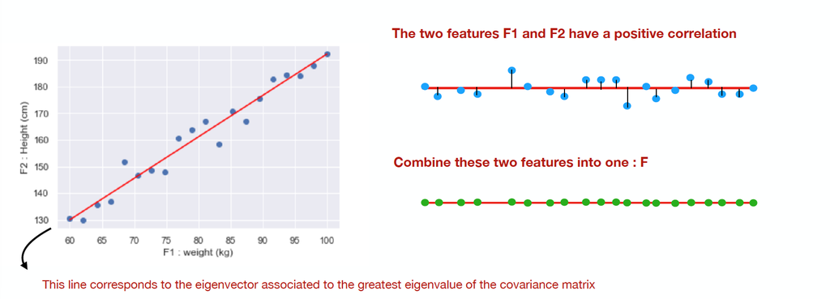

### PCA pseudo-code (see linear algebra course for more details)

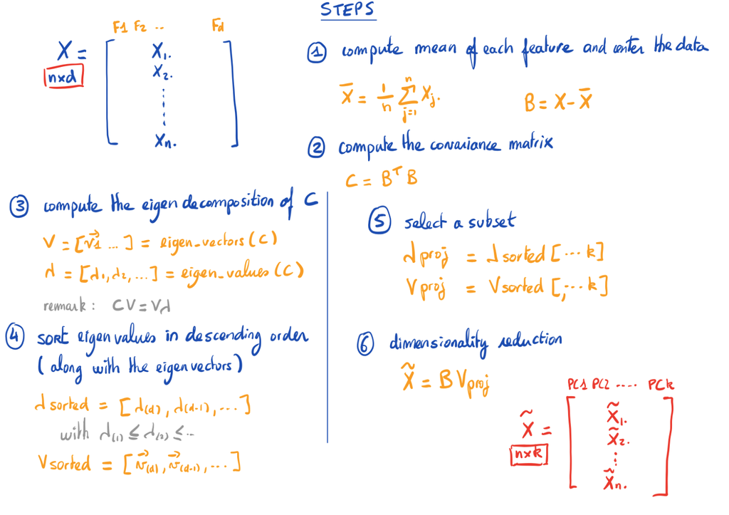

### PCA : some limits

- **Model performance:** PCA can reduce the model performance on datasets with low feature (linear) correlation
- **Interpretability:** each principal component (PC1, PC2, ...) is a combination of original features (F1, F2, ...) $\implies$ principal components are not interpretable

## (optional) Singular-Value Decomposition (SVD)

- **Matrix factorization** method (like LU decomposition)
- The singular value decomposition decomposes a matrix $X$ into $$ X = U \times S\times V^T $$ with
  - $U, V$ **orthogonal matrices** and
  - $S$ a **diagonal matrix** with singular values (e.g. square roots of the eigenvalues) of $X^TX$ as entries (assumed to be sorted in descending order)
- We can reduce the matrix $X$ by truncating $U$, $S$ and $V$:

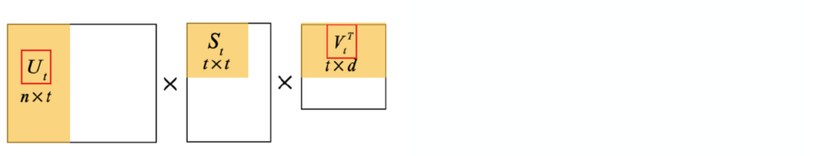